# In-class Week 12

- INFO 5871-001
- Robin Burke
- Fall 2019

An initital look at text mining

## Imports

```python
# The usual
import pandas as pd
import numpy as np
import matplotlib.pyplot as plt
import seaborn as sns

# Regression tools
import statsmodels.formula.api as sm
from scipy.special import expit
from statsmodels.graphics.gofplots import qqplot

# Text tools
import nltk
from nltk.stem import WordNetLemmatizer
from nltk.tokenize import word_tokenize
from nltk.corpus import stopwords
from wordcloud import WordCloud
```

## Import gutenberg corpera

In particular, we will work with Jane Austen's *Emma*

```python
nltk.download('gutenberg')
emma = nltk.corpus.gutenberg.words('austen-emma.txt')
```

## Preprocessing

### Stopwords

And lower case

```python
from nltk.corpus import stopwords
english_stops = set(stopwords.words('english'))

emma_lower = [word.lower() for word in emma if word.isalpha()]

emma_np = [word for word in emma_lower if word not in english_stops]

emma_np[0:10]
```

```
['emma',
 'jane',
 'austen',
 'volume',
 'chapter',
 'emma',
 'woodhouse',
 'handsome',
 'clever',
 'rich']
```

### Substitute lemmas

```python
lemmatizer = WordNetLemmatizer()

emma_lem = [lemmatizer.lemmatize(word) for word in emma_np]

emma_lem[0:10]
```

```
['emma',
 'jane',
 'austen',
 'volume',
 'chapter',
 'emma',
 'woodhouse',
 'handsome',
 'clever',
 'rich']
```

## Calculate frequency distribution

```python
fdist = nltk.FreqDist(emma_lem)

for word, frequency in fdist.most_common(100):
    print(u'{};{}'.format(word, frequency))
```

```
mr;1852
emma;865
could;837
would;820
miss;600
must;567
harriet;506
much;486
said;484
thing;460
one;456
weston;448
every;435
think;406
well;401
knightley;389
elton;385
know;367
little;359
never;358
good;358
say;341
might;326
woodhouse;313
time;307
jane;301
quite;282
thought;264
great;264
friend;259
nothing;256
dear;243
day;242
fairfax;241
churchill;239
always;238
man;235
see;225
soon;224
may;221
```

[output cut: 45 more lines]

```
room;132
however;131
enough;129
manner;128
take;127
love;126
happy;125
highbury;125
yes;125
pleasure;124
party;123
last;121
going;121
heard;120
came;119
```

## Create a word cloud from the top 100

```python
top100 = fdist.most_common(100)
```

```python
top100_dict = {word:freq for word, freq in top100}
```

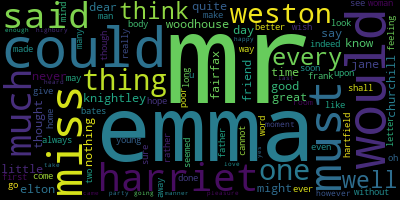

```python
wc_gen = WordCloud()
wc_gen.generate_from_frequencies(top100_dict).to_image()
```

## Study the sentence level

Can we predict which sentences will be about men? Start with a sentence-level data frame.

```python
emma_df = pd.DataFrame({'sentence': nltk.corpus.gutenberg.sents('austen-emma.txt')})
```

```python
emma_df.head()
```

|  | sentence |
| --- | --- |
| 0 | [[, Emma, by, Jane, Austen, 1816, ]] |
| 1 | [VOLUME, I] |
| 2 | [CHAPTER, I] |
| 3 | [Emma, Woodhouse, ,, handsome, ,, clever, ,, a... |
| 4 | [She, was, the, youngest, of, the, two, daught... |

### Add features for chapter and volume

```python
vol = 0
cha = 0

vol_lst = []
cha_lst = []

for sent in emma_df.sentence:
    if 'VOLUME' in sent:
        vol = vol+1
        cha = 0
    if 'CHAPTER' in sent or 'Scena' in sent:
        cha = cha+1
    vol_lst.append(vol)
    cha_lst.append(cha)

emma_df['volume'] = vol_lst
emma_df['chapter'] = cha_lst
```

```python
pd.value_counts(emma_df.volume)
```

```
2    2754
3    2669
1    2328
0       1
Name: volume, dtype: int64
```

```python
pd.value_counts(emma_df.chapter)
```

```
8     658
9     612
6     557
11    489
18    488
7     482
10    463
14    402
5     399
15    393
16    391
12    386
2     385
1     361
4     358
3     332
13    314
17    247
19     31
0       4
Name: chapter, dtype: int64
```

### Function to convert a text to binary features

Based on the fwords input. Only these words will be feature-ized

```python
def convert_to_features (text, fwords):
    feature_dict = {}
    tokens = word_tokenize(str(text))
    lower = [word.lower() for word in tokens]
    lems = [lemmatizer.lemmatize(word) for word in lower]
    for word in fwords:
        if word in lems:
            feature_dict[word] = 1
        else:
            feature_dict[word] = 0
    return feature_dict
```

### Function to convert feature dictionaries to individual Series

```python
def feature_to_series (feature_dicts, fword):
    return pd.Series([feature_dict[fword] for feature_dict in feature_dicts])
```

### Extract top 25 words

```python
top25 = fdist.most_common(25)
top25_dict = {word:freq for word, freq in top25}
fwords = list(top25_dict.keys())
```

### Create features for the sentences

```python
entry_dicts = emma_df.sentence.map(lambda text: convert_to_features(' '.join(text), fwords))
```

### Create a word-feature data frame

Binary term-document matrix where the documents are sentences.

```python
entry_series_dict = {fword:feature_to_series(entry_dicts, fword) for fword in fwords}
feature_df = pd.DataFrame(entry_series_dict)
print (feature_df.shape)
feature_df.head()
```

```
(7752, 25)
```

|  | mr | emma | could | would | miss | must | harriet | much | said | thing | ... | knightley | elton | know | little | never | good | say | might | woodhouse | time |
| --- | --- | --- | --- | --- | --- | --- | --- | --- | --- | --- | --- | --- | --- | --- | --- | --- | --- | --- | --- | --- | --- |
| 0 | 0 | 1 | 0 | 0 | 0 | 0 | 0 | 0 | 0 | 0 | ... | 0 | 0 | 0 | 0 | 0 | 0 | 0 | 0 | 0 | 0 |
| 1 | 0 | 0 | 0 | 0 | 0 | 0 | 0 | 0 | 0 | 0 | ... | 0 | 0 | 0 | 0 | 0 | 0 | 0 | 0 | 0 | 0 |
| 2 | 0 | 0 | 0 | 0 | 0 | 0 | 0 | 0 | 0 | 0 | ... | 0 | 0 | 0 | 0 | 0 | 0 | 0 | 0 | 0 | 0 |
| 3 | 0 | 1 | 0 | 0 | 0 | 0 | 0 | 0 | 0 | 0 | ... | 0 | 0 | 0 | 1 | 0 | 0 | 0 | 0 | 1 | 0 |
| 4 | 0 | 0 | 0 | 0 | 0 | 0 | 0 | 0 | 0 | 0 | ... | 0 | 0 | 0 | 0 | 0 | 0 | 0 | 0 | 0 | 0 |

5 rows × 25 columns

### Combine with the original data frame

```python
emma_df2 = pd.concat([emma_df, feature_df], axis=1)
```

```python
emma_df2.columns
```

```
Index(['sentence', 'volume', 'chapter', 'mr', 'emma', 'could', 'would', 'miss',
       'must', 'harriet', 'much', 'said', 'thing', 'one', 'weston', 'every',
       'think', 'well', 'knightley', 'elton', 'know', 'little', 'never',
       'good', 'say', 'might', 'woodhouse', 'time'],
      dtype='object')
```

## Logistic regression

Predict the appearance of Mr. our proxy for the sentence being about a man. Obviously, the last names are important, but there are also women with these last names.

We will use backward selection on p-value because it is faster.

### Check for correlation

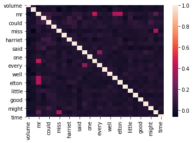

```python
sns.heatmap(emma_df2.corr())
```

```python
(emma_df2.corr() > 0.8).sum()
```

```
volume       1
chapter      1
mr           1
emma         1
could        1
would        1
miss         1
must         1
harriet      1
much         1
said         1
thing        1
one          1
weston       1
every        1
think        1
well         1
knightley    1
elton        1
know         1
little       1
never        1
good         1
say          1
might        1
woodhouse    1
time         1
dtype: int64
```

```python
(emma_df2.corr() < -0.8).sum()
```

```
volume       0
chapter      0
mr           0
emma         0
could        0
would        0
miss         0
must         0
harriet      0
much         0
said         0
thing        0
one          0
weston       0
every        0
think        0
well         0
knightley    0
elton        0
know         0
little       0
never        0
good         0
say          0
might        0
woodhouse    0
time         0
dtype: int64
```

### Run the regressions

```python
reg1 = sm.logit(formula='mr ~ emma + could + would + miss + \
       must + harriet + much + said + thing + one + weston + every + \
       think + well + knightley + elton + know + little + never + \
       good + say + might + woodhouse + time + volume + chapter',
               data = emma_df2).fit()
```

```
Optimization terminated successfully.
         Current function value: 0.255661
         Iterations 7
```

```python
reg1.summary()
```

Logit Regression Results

| Dep. Variable: | mr | No. Observations: | 7752 |
| --- | --- | --- | --- |
| Model: | Logit | Df Residuals: | 7725 |
| Method: | MLE | Df Model: | 26 |
| Date: | Mon, 11 Nov 2019 | Pseudo R-squ.: | 0.4796 |
| Time: | 15:26:40 | Log-Likelihood: | -1981.9 |
| converged: | True | LL-Null: | -3808.2 |
| Covariance Type: | nonrobust | LLR p-value: | 0.000 |

|  | coef | std err | z | P>\|z\| | [0.025 | 0.975] |
| --- | --- | --- | --- | --- | --- | --- |
| Intercept | -2.5461 | 0.147 | -17.279 | 0.000 | -2.835 | -2.257 |
| emma | 0.2811 | 0.135 | 2.075 | 0.038 | 0.016 | 0.547 |
| could | 0.3175 | 0.138 | 2.303 | 0.021 | 0.047 | 0.588 |
| would | 0.1881 | 0.145 | 1.298 | 0.194 | -0.096 | 0.472 |
| miss | -0.7512 | 0.185 | -4.063 | 0.000 | -1.114 | -0.389 |
| must | -0.2142 | 0.175 | -1.221 | 0.222 | -0.558 | 0.130 |
| harriet | -0.3261 | 0.194 | -1.684 | 0.092 | -0.706 | 0.053 |
| much | 0.1755 | 0.174 | 1.009 | 0.313 | -0.165 | 0.516 |
| said | 0.1213 | 0.172 | 0.704 | 0.481 | -0.216 | 0.459 |
| thing | 0.1777 | 0.181 | 0.979 | 0.328 | -0.178 | 0.533 |
| one | 0.4967 | 0.174 | 2.859 | 0.004 | 0.156 | 0.837 |
| weston | 5.1856 | 0.203 | 25.566 | 0.000 | 4.788 | 5.583 |
| every | 0.4044 | 0.187 | 2.167 | 0.030 | 0.039 | 0.770 |
| think | 0.0654 | 0.187 | 0.350 | 0.726 | -0.301 | 0.431 |
| well | 0.3662 | 0.182 | 2.009 | 0.045 | 0.009 | 0.723 |
| knightley | 4.4090 | 0.168 | 26.244 | 0.000 | 4.080 | 4.738 |
| elton | 5.1133 | 0.216 | 23.706 | 0.000 | 4.691 | 5.536 |
| know | 0.2768 | 0.191 | 1.452 | 0.147 | -0.097 | 0.651 |
| little | 0.2556 | 0.198 | 1.292 | 0.196 | -0.132 | 0.644 |
| never | 0.3956 | 0.194 | 2.037 | 0.042 | 0.015 | 0.776 |
| good | 0.0022 | 0.203 | 0.011 | 0.991 | -0.396 | 0.400 |
| say | 0.2749 | 0.193 | 1.427 | 0.154 | -0.103 | 0.653 |
| might | 0.3317 | 0.211 | 1.573 | 0.116 | -0.082 | 0.745 |
| woodhouse | 2.7746 | 0.181 | 15.334 | 0.000 | 2.420 | 3.129 |
| time | 0.1016 | 0.223 | 0.455 | 0.649 | -0.336 | 0.540 |
| volume | -0.0673 | 0.055 | -1.227 | 0.220 | -0.175 | 0.040 |
| chapter | -0.0216 | 0.009 | -2.422 | 0.015 | -0.039 | -0.004 |

```python
reg1.pvalues.idxmax()
```

```
'good'
```

```python
reg2 = sm.logit(formula='mr ~ emma + could + would + miss + \
       must + harriet + much + said + thing + one + weston + every + \
       think + well + knightley + elton + know + little + never + \
       say + might + woodhouse + time + volume + chapter',
               data = emma_df2).fit()
```

```
Optimization terminated successfully.
         Current function value: 0.255661
         Iterations 7
```

```python
reg2.summary()
```

Logit Regression Results

| Dep. Variable: | mr | No. Observations: | 7752 |
| --- | --- | --- | --- |
| Model: | Logit | Df Residuals: | 7726 |
| Method: | MLE | Df Model: | 25 |
| Date: | Mon, 11 Nov 2019 | Pseudo R-squ.: | 0.4796 |
| Time: | 15:26:40 | Log-Likelihood: | -1981.9 |
| converged: | True | LL-Null: | -3808.2 |
| Covariance Type: | nonrobust | LLR p-value: | 0.000 |

|  | coef | std err | z | P>\|z\| | [0.025 | 0.975] |
| --- | --- | --- | --- | --- | --- | --- |
| Intercept | -2.5459 | 0.147 | -17.317 | 0.000 | -2.834 | -2.258 |
| emma | 0.2810 | 0.135 | 2.075 | 0.038 | 0.016 | 0.547 |
| could | 0.3176 | 0.138 | 2.304 | 0.021 | 0.047 | 0.588 |
| would | 0.1882 | 0.145 | 1.300 | 0.193 | -0.095 | 0.472 |
| miss | -0.7512 | 0.185 | -4.063 | 0.000 | -1.114 | -0.389 |
| must | -0.2142 | 0.175 | -1.221 | 0.222 | -0.558 | 0.130 |
| harriet | -0.3261 | 0.194 | -1.684 | 0.092 | -0.706 | 0.053 |
| much | 0.1755 | 0.174 | 1.010 | 0.313 | -0.165 | 0.516 |
| said | 0.1213 | 0.172 | 0.704 | 0.481 | -0.216 | 0.459 |
| thing | 0.1778 | 0.181 | 0.980 | 0.327 | -0.178 | 0.533 |
| one | 0.4967 | 0.174 | 2.859 | 0.004 | 0.156 | 0.837 |
| weston | 5.1856 | 0.203 | 25.574 | 0.000 | 4.788 | 5.583 |
| every | 0.4045 | 0.187 | 2.168 | 0.030 | 0.039 | 0.770 |
| think | 0.0655 | 0.187 | 0.351 | 0.726 | -0.300 | 0.431 |
| well | 0.3662 | 0.182 | 2.009 | 0.045 | 0.009 | 0.723 |
| knightley | 4.4090 | 0.168 | 26.247 | 0.000 | 4.080 | 4.738 |
| elton | 5.1134 | 0.216 | 23.712 | 0.000 | 4.691 | 5.536 |
| know | 0.2768 | 0.191 | 1.452 | 0.146 | -0.097 | 0.650 |
| little | 0.2557 | 0.198 | 1.294 | 0.196 | -0.132 | 0.643 |
| never | 0.3956 | 0.194 | 2.037 | 0.042 | 0.015 | 0.776 |
| say | 0.2750 | 0.193 | 1.428 | 0.153 | -0.103 | 0.652 |
| might | 0.3317 | 0.211 | 1.574 | 0.116 | -0.081 | 0.745 |
| woodhouse | 2.7746 | 0.181 | 15.340 | 0.000 | 2.420 | 3.129 |
| time | 0.1016 | 0.223 | 0.455 | 0.649 | -0.336 | 0.540 |
| volume | -0.0673 | 0.055 | -1.228 | 0.220 | -0.175 | 0.040 |
| chapter | -0.0217 | 0.009 | -2.422 | 0.015 | -0.039 | -0.004 |

```python
reg2.pvalues.idxmax()
```

```
'think'
```

```python
reg3 = sm.logit(formula='mr ~ emma + could + would + miss + \
       must + harriet + much + said + thing + one + weston + every + \
       well + knightley + elton + know + little + never + \
       say + might + woodhouse + time + volume + chapter',
               data = emma_df2).fit()
```

```
Optimization terminated successfully.
         Current function value: 0.255669
         Iterations 7
```

```python
reg3.summary()
```

Logit Regression Results

| Dep. Variable: | mr | No. Observations: | 7752 |
| --- | --- | --- | --- |
| Model: | Logit | Df Residuals: | 7727 |
| Method: | MLE | Df Model: | 24 |
| Date: | Mon, 11 Nov 2019 | Pseudo R-squ.: | 0.4796 |
| Time: | 15:26:40 | Log-Likelihood: | -1981.9 |
| converged: | True | LL-Null: | -3808.2 |
| Covariance Type: | nonrobust | LLR p-value: | 0.000 |

|  | coef | std err | z | P>\|z\| | [0.025 | 0.975] |
| --- | --- | --- | --- | --- | --- | --- |
| Intercept | -2.5424 | 0.147 | -17.336 | 0.000 | -2.830 | -2.255 |
| emma | 0.2810 | 0.135 | 2.075 | 0.038 | 0.016 | 0.546 |
| could | 0.3175 | 0.138 | 2.304 | 0.021 | 0.047 | 0.588 |
| would | 0.1907 | 0.144 | 1.320 | 0.187 | -0.092 | 0.474 |
| miss | -0.7482 | 0.185 | -4.052 | 0.000 | -1.110 | -0.386 |
| must | -0.2125 | 0.175 | -1.211 | 0.226 | -0.556 | 0.131 |
| harriet | -0.3241 | 0.193 | -1.676 | 0.094 | -0.703 | 0.055 |
| much | 0.1767 | 0.174 | 1.017 | 0.309 | -0.164 | 0.517 |
| said | 0.1228 | 0.172 | 0.713 | 0.476 | -0.215 | 0.460 |
| thing | 0.1787 | 0.181 | 0.985 | 0.325 | -0.177 | 0.534 |
| one | 0.4973 | 0.174 | 2.862 | 0.004 | 0.157 | 0.838 |
| weston | 5.1845 | 0.203 | 25.574 | 0.000 | 4.787 | 5.582 |
| every | 0.4046 | 0.187 | 2.167 | 0.030 | 0.039 | 0.770 |
| well | 0.3701 | 0.182 | 2.035 | 0.042 | 0.014 | 0.727 |
| knightley | 4.4098 | 0.168 | 26.253 | 0.000 | 4.081 | 4.739 |
| elton | 5.1122 | 0.216 | 23.710 | 0.000 | 4.690 | 5.535 |
| know | 0.2771 | 0.191 | 1.454 | 0.146 | -0.096 | 0.651 |
| little | 0.2591 | 0.197 | 1.312 | 0.189 | -0.128 | 0.646 |
| never | 0.3983 | 0.194 | 2.053 | 0.040 | 0.018 | 0.779 |
| say | 0.2755 | 0.193 | 1.431 | 0.153 | -0.102 | 0.653 |
| might | 0.3336 | 0.211 | 1.584 | 0.113 | -0.079 | 0.746 |
| woodhouse | 2.7753 | 0.181 | 15.346 | 0.000 | 2.421 | 3.130 |
| time | 0.1027 | 0.223 | 0.460 | 0.645 | -0.335 | 0.540 |
| volume | -0.0682 | 0.055 | -1.247 | 0.213 | -0.176 | 0.039 |
| chapter | -0.0216 | 0.009 | -2.418 | 0.016 | -0.039 | -0.004 |

```python
reg3.pvalues.idxmax()
```

```
'time'
```

```python
reg4 = sm.logit(formula='mr ~ emma + could + would + miss + \
       must + harriet + much + said + thing + one + weston + every + \
       well + knightley + elton + know + little + never + \
       say + might + woodhouse + volume + chapter',
               data = emma_df2).fit()
```

```
Optimization terminated successfully.
         Current function value: 0.255682
         Iterations 7
```

```python
reg4.summary()
```

Logit Regression Results

| Dep. Variable: | mr | No. Observations: | 7752 |
| --- | --- | --- | --- |
| Model: | Logit | Df Residuals: | 7728 |
| Method: | MLE | Df Model: | 23 |
| Date: | Mon, 11 Nov 2019 | Pseudo R-squ.: | 0.4795 |
| Time: | 15:26:41 | Log-Likelihood: | -1982.0 |
| converged: | True | LL-Null: | -3808.2 |
| Covariance Type: | nonrobust | LLR p-value: | 0.000 |

|  | coef | std err | z | P>\|z\| | [0.025 | 0.975] |
| --- | --- | --- | --- | --- | --- | --- |
| Intercept | -2.5404 | 0.147 | -17.329 | 0.000 | -2.828 | -2.253 |
| emma | 0.2804 | 0.135 | 2.070 | 0.038 | 0.015 | 0.546 |
| could | 0.3198 | 0.138 | 2.323 | 0.020 | 0.050 | 0.590 |
| would | 0.1906 | 0.144 | 1.319 | 0.187 | -0.093 | 0.474 |
| miss | -0.7490 | 0.185 | -4.054 | 0.000 | -1.111 | -0.387 |
| must | -0.2085 | 0.175 | -1.191 | 0.234 | -0.552 | 0.135 |
| harriet | -0.3223 | 0.193 | -1.667 | 0.096 | -0.701 | 0.057 |
| much | 0.1807 | 0.174 | 1.041 | 0.298 | -0.159 | 0.521 |
| said | 0.1237 | 0.172 | 0.718 | 0.473 | -0.214 | 0.461 |
| thing | 0.1777 | 0.181 | 0.979 | 0.327 | -0.178 | 0.533 |
| one | 0.4984 | 0.174 | 2.869 | 0.004 | 0.158 | 0.839 |
| weston | 5.1857 | 0.203 | 25.583 | 0.000 | 4.788 | 5.583 |
| every | 0.4071 | 0.187 | 2.181 | 0.029 | 0.041 | 0.773 |
| well | 0.3686 | 0.182 | 2.027 | 0.043 | 0.012 | 0.725 |
| knightley | 4.4109 | 0.168 | 26.263 | 0.000 | 4.082 | 4.740 |
| elton | 5.1149 | 0.216 | 23.732 | 0.000 | 4.692 | 5.537 |
| know | 0.2792 | 0.191 | 1.465 | 0.143 | -0.094 | 0.653 |
| little | 0.2625 | 0.197 | 1.331 | 0.183 | -0.124 | 0.649 |
| never | 0.3995 | 0.194 | 2.058 | 0.040 | 0.019 | 0.780 |
| say | 0.2771 | 0.192 | 1.440 | 0.150 | -0.100 | 0.654 |
| might | 0.3378 | 0.210 | 1.607 | 0.108 | -0.074 | 0.750 |
| woodhouse | 2.7746 | 0.181 | 15.340 | 0.000 | 2.420 | 3.129 |
| volume | -0.0680 | 0.055 | -1.243 | 0.214 | -0.175 | 0.039 |
| chapter | -0.0216 | 0.009 | -2.418 | 0.016 | -0.039 | -0.004 |

```python
reg4.pvalues.idxmax()
```

```
'said'
```

```python
reg5 = sm.logit(formula='mr ~ emma + could + would + miss + \
       must + harriet + much + thing + one + weston + every + \
       well + knightley + elton + know + little + never + \
       say + might + woodhouse + volume + chapter',
               data = emma_df2).fit()
```

```
Optimization terminated successfully.
         Current function value: 0.255715
         Iterations 7
```

```python
reg5.summary()
```

Logit Regression Results

| Dep. Variable: | mr | No. Observations: | 7752 |
| --- | --- | --- | --- |
| Model: | Logit | Df Residuals: | 7729 |
| Method: | MLE | Df Model: | 22 |
| Date: | Mon, 11 Nov 2019 | Pseudo R-squ.: | 0.4795 |
| Time: | 15:26:41 | Log-Likelihood: | -1982.3 |
| converged: | True | LL-Null: | -3808.2 |
| Covariance Type: | nonrobust | LLR p-value: | 0.000 |

|  | coef | std err | z | P>\|z\| | [0.025 | 0.975] |
| --- | --- | --- | --- | --- | --- | --- |
| Intercept | -2.5352 | 0.146 | -17.326 | 0.000 | -2.822 | -2.248 |
| emma | 0.2900 | 0.135 | 2.150 | 0.032 | 0.026 | 0.554 |
| could | 0.3186 | 0.138 | 2.314 | 0.021 | 0.049 | 0.588 |
| would | 0.1901 | 0.144 | 1.315 | 0.188 | -0.093 | 0.473 |
| miss | -0.7505 | 0.185 | -4.061 | 0.000 | -1.113 | -0.388 |
| must | -0.2101 | 0.175 | -1.199 | 0.230 | -0.554 | 0.133 |
| harriet | -0.3213 | 0.193 | -1.661 | 0.097 | -0.700 | 0.058 |
| much | 0.1834 | 0.174 | 1.057 | 0.291 | -0.157 | 0.523 |
| thing | 0.1807 | 0.181 | 0.997 | 0.319 | -0.175 | 0.536 |
| one | 0.5027 | 0.174 | 2.896 | 0.004 | 0.162 | 0.843 |
| weston | 5.1903 | 0.203 | 25.614 | 0.000 | 4.793 | 5.587 |
| every | 0.4087 | 0.187 | 2.190 | 0.029 | 0.043 | 0.774 |
| well | 0.3724 | 0.182 | 2.046 | 0.041 | 0.016 | 0.729 |
| knightley | 4.4176 | 0.168 | 26.337 | 0.000 | 4.089 | 4.746 |
| elton | 5.1155 | 0.216 | 23.735 | 0.000 | 4.693 | 5.538 |
| know | 0.2798 | 0.191 | 1.469 | 0.142 | -0.094 | 0.653 |
| little | 0.2572 | 0.197 | 1.304 | 0.192 | -0.129 | 0.644 |
| never | 0.3984 | 0.194 | 2.051 | 0.040 | 0.018 | 0.779 |
| say | 0.2763 | 0.193 | 1.435 | 0.151 | -0.101 | 0.654 |
| might | 0.3359 | 0.210 | 1.598 | 0.110 | -0.076 | 0.748 |
| woodhouse | 2.7796 | 0.181 | 15.372 | 0.000 | 2.425 | 3.134 |
| volume | -0.0680 | 0.055 | -1.242 | 0.214 | -0.175 | 0.039 |
| chapter | -0.0216 | 0.009 | -2.414 | 0.016 | -0.039 | -0.004 |

```python
reg5.pvalues.idxmax()
```

```
'thing'
```

```python
reg6 = sm.logit(formula='mr ~ emma + could + would + miss + \
       must + harriet + much + one + weston + every + \
       well + knightley + elton + know + little + never + \
       say + might + woodhouse + volume + chapter',
               data = emma_df2).fit()
```

```
Optimization terminated successfully.
         Current function value: 0.255778
         Iterations 7
```

```python
reg6.summary()
```

Logit Regression Results

| Dep. Variable: | mr | No. Observations: | 7752 |
| --- | --- | --- | --- |
| Model: | Logit | Df Residuals: | 7730 |
| Method: | MLE | Df Model: | 21 |
| Date: | Mon, 11 Nov 2019 | Pseudo R-squ.: | 0.4793 |
| Time: | 15:26:41 | Log-Likelihood: | -1982.8 |
| converged: | True | LL-Null: | -3808.2 |
| Covariance Type: | nonrobust | LLR p-value: | 0.000 |

|  | coef | std err | z | P>\|z\| | [0.025 | 0.975] |
| --- | --- | --- | --- | --- | --- | --- |
| Intercept | -2.5280 | 0.146 | -17.303 | 0.000 | -2.814 | -2.242 |
| emma | 0.2903 | 0.135 | 2.152 | 0.031 | 0.026 | 0.555 |
| could | 0.3242 | 0.138 | 2.357 | 0.018 | 0.055 | 0.594 |
| would | 0.1954 | 0.144 | 1.354 | 0.176 | -0.088 | 0.478 |
| miss | -0.7521 | 0.185 | -4.070 | 0.000 | -1.114 | -0.390 |
| must | -0.2098 | 0.175 | -1.198 | 0.231 | -0.553 | 0.133 |
| harriet | -0.3257 | 0.193 | -1.684 | 0.092 | -0.705 | 0.053 |
| much | 0.1873 | 0.173 | 1.081 | 0.280 | -0.152 | 0.527 |
| one | 0.5104 | 0.174 | 2.941 | 0.003 | 0.170 | 0.851 |
| weston | 5.1873 | 0.203 | 25.608 | 0.000 | 4.790 | 5.584 |
| every | 0.4677 | 0.177 | 2.645 | 0.008 | 0.121 | 0.814 |
| well | 0.3734 | 0.182 | 2.052 | 0.040 | 0.017 | 0.730 |
| knightley | 4.4122 | 0.168 | 26.324 | 0.000 | 4.084 | 4.741 |
| elton | 5.1184 | 0.216 | 23.738 | 0.000 | 4.696 | 5.541 |
| know | 0.2849 | 0.190 | 1.497 | 0.134 | -0.088 | 0.658 |
| little | 0.2628 | 0.197 | 1.334 | 0.182 | -0.123 | 0.649 |
| never | 0.4029 | 0.194 | 2.077 | 0.038 | 0.023 | 0.783 |
| say | 0.2950 | 0.192 | 1.538 | 0.124 | -0.081 | 0.671 |
| might | 0.3397 | 0.210 | 1.615 | 0.106 | -0.073 | 0.752 |
| woodhouse | 2.7810 | 0.181 | 15.385 | 0.000 | 2.427 | 3.135 |
| volume | -0.0684 | 0.055 | -1.251 | 0.211 | -0.176 | 0.039 |
| chapter | -0.0217 | 0.009 | -2.428 | 0.015 | -0.039 | -0.004 |

```python
reg6.pvalues.idxmax()
```

```
'much'
```

```python
reg7 = sm.logit(formula='mr ~ emma + could + would + miss + \
       must + harriet + one + weston + every + \
       well + knightley + elton + know + little + never + \
       say + might + woodhouse + volume + chapter',
               data = emma_df2).fit()
```

```
Optimization terminated successfully.
         Current function value: 0.255851
         Iterations 7
```

```python
reg7.summary()
```

Logit Regression Results

| Dep. Variable: | mr | No. Observations: | 7752 |
| --- | --- | --- | --- |
| Model: | Logit | Df Residuals: | 7731 |
| Method: | MLE | Df Model: | 20 |
| Date: | Mon, 11 Nov 2019 | Pseudo R-squ.: | 0.4792 |
| Time: | 15:26:41 | Log-Likelihood: | -1983.4 |
| converged: | True | LL-Null: | -3808.2 |
| Covariance Type: | nonrobust | LLR p-value: | 0.000 |

|  | coef | std err | z | P>\|z\| | [0.025 | 0.975] |
| --- | --- | --- | --- | --- | --- | --- |
| Intercept | -2.5199 | 0.146 | -17.279 | 0.000 | -2.806 | -2.234 |
| emma | 0.2940 | 0.135 | 2.183 | 0.029 | 0.030 | 0.558 |
| could | 0.3354 | 0.137 | 2.449 | 0.014 | 0.067 | 0.604 |
| would | 0.2053 | 0.144 | 1.426 | 0.154 | -0.077 | 0.487 |
| miss | -0.7554 | 0.185 | -4.090 | 0.000 | -1.117 | -0.393 |
| must | -0.2033 | 0.175 | -1.161 | 0.245 | -0.546 | 0.140 |
| harriet | -0.3167 | 0.193 | -1.642 | 0.101 | -0.695 | 0.061 |
| one | 0.5129 | 0.174 | 2.956 | 0.003 | 0.173 | 0.853 |
| weston | 5.1930 | 0.203 | 25.640 | 0.000 | 4.796 | 5.590 |
| every | 0.4722 | 0.177 | 2.669 | 0.008 | 0.125 | 0.819 |
| well | 0.3771 | 0.182 | 2.074 | 0.038 | 0.021 | 0.733 |
| knightley | 4.4131 | 0.168 | 26.327 | 0.000 | 4.085 | 4.742 |
| elton | 5.1245 | 0.216 | 23.772 | 0.000 | 4.702 | 5.547 |
| know | 0.2882 | 0.190 | 1.514 | 0.130 | -0.085 | 0.661 |
| little | 0.2737 | 0.197 | 1.392 | 0.164 | -0.112 | 0.659 |
| never | 0.4041 | 0.194 | 2.085 | 0.037 | 0.024 | 0.784 |
| say | 0.3017 | 0.192 | 1.574 | 0.116 | -0.074 | 0.677 |
| might | 0.3439 | 0.210 | 1.636 | 0.102 | -0.068 | 0.756 |
| woodhouse | 2.7909 | 0.180 | 15.464 | 0.000 | 2.437 | 3.145 |
| volume | -0.0701 | 0.055 | -1.283 | 0.199 | -0.177 | 0.037 |
| chapter | -0.0216 | 0.009 | -2.419 | 0.016 | -0.039 | -0.004 |

```python
reg7.pvalues.idxmax()
```

```
'must'
```

```python
reg8 = sm.logit(formula='mr ~ emma + could + would + miss + \
       harriet + one + weston + every + \
       well + knightley + elton + know + little + never + \
       say + might + woodhouse + volume + chapter',
               data = emma_df2).fit()
```

```
Optimization terminated successfully.
         Current function value: 0.255941
         Iterations 7
```

```python
reg8.summary()
```

Logit Regression Results

| Dep. Variable: | mr | No. Observations: | 7752 |
| --- | --- | --- | --- |
| Model: | Logit | Df Residuals: | 7732 |
| Method: | MLE | Df Model: | 19 |
| Date: | Mon, 11 Nov 2019 | Pseudo R-squ.: | 0.4790 |
| Time: | 15:26:41 | Log-Likelihood: | -1984.1 |
| converged: | True | LL-Null: | -3808.2 |
| Covariance Type: | nonrobust | LLR p-value: | 0.000 |

|  | coef | std err | z | P>\|z\| | [0.025 | 0.975] |
| --- | --- | --- | --- | --- | --- | --- |
| Intercept | -2.5251 | 0.146 | -17.327 | 0.000 | -2.811 | -2.240 |
| emma | 0.2921 | 0.135 | 2.168 | 0.030 | 0.028 | 0.556 |
| could | 0.3283 | 0.137 | 2.399 | 0.016 | 0.060 | 0.597 |
| would | 0.2022 | 0.144 | 1.406 | 0.160 | -0.080 | 0.484 |
| miss | -0.7638 | 0.185 | -4.136 | 0.000 | -1.126 | -0.402 |
| harriet | -0.3259 | 0.193 | -1.689 | 0.091 | -0.704 | 0.052 |
| one | 0.5025 | 0.174 | 2.896 | 0.004 | 0.162 | 0.843 |
| weston | 5.1863 | 0.202 | 25.625 | 0.000 | 4.790 | 5.583 |
| every | 0.4597 | 0.176 | 2.605 | 0.009 | 0.114 | 0.805 |
| well | 0.3688 | 0.182 | 2.031 | 0.042 | 0.013 | 0.725 |
| knightley | 4.4137 | 0.168 | 26.332 | 0.000 | 4.085 | 4.742 |
| elton | 5.1209 | 0.215 | 23.775 | 0.000 | 4.699 | 5.543 |
| know | 0.2819 | 0.190 | 1.483 | 0.138 | -0.091 | 0.655 |
| little | 0.2707 | 0.197 | 1.376 | 0.169 | -0.115 | 0.656 |
| never | 0.4036 | 0.194 | 2.082 | 0.037 | 0.024 | 0.783 |
| say | 0.2938 | 0.192 | 1.533 | 0.125 | -0.082 | 0.669 |
| might | 0.3371 | 0.210 | 1.604 | 0.109 | -0.075 | 0.749 |
| woodhouse | 2.7912 | 0.180 | 15.466 | 0.000 | 2.437 | 3.145 |
| volume | -0.0709 | 0.055 | -1.297 | 0.195 | -0.178 | 0.036 |
| chapter | -0.0217 | 0.009 | -2.433 | 0.015 | -0.039 | -0.004 |

```python
reg8.pvalues.idxmax()
```

```
'volume'
```

```python
reg9 = sm.logit(formula='mr ~ emma + could + would + miss + \
       harriet + one + weston + every + \
       well + knightley + elton + know + little + never + \
       say + might + woodhouse + chapter',
               data = emma_df2).fit()
```

```
Optimization terminated successfully.
         Current function value: 0.256049
         Iterations 7
```

```python
reg9.summary()
```

Logit Regression Results

| Dep. Variable: | mr | No. Observations: | 7752 |
| --- | --- | --- | --- |
| Model: | Logit | Df Residuals: | 7733 |
| Method: | MLE | Df Model: | 18 |
| Date: | Mon, 11 Nov 2019 | Pseudo R-squ.: | 0.4788 |
| Time: | 15:26:41 | Log-Likelihood: | -1984.9 |
| converged: | True | LL-Null: | -3808.2 |
| Covariance Type: | nonrobust | LLR p-value: | 0.000 |

|  | coef | std err | z | P>\|z\| | [0.025 | 0.975] |
| --- | --- | --- | --- | --- | --- | --- |
| Intercept | -2.6619 | 0.102 | -26.193 | 0.000 | -2.861 | -2.463 |
| emma | 0.2864 | 0.135 | 2.126 | 0.033 | 0.022 | 0.550 |
| could | 0.3273 | 0.137 | 2.391 | 0.017 | 0.059 | 0.596 |
| would | 0.1996 | 0.144 | 1.387 | 0.165 | -0.082 | 0.481 |
| miss | -0.7785 | 0.185 | -4.217 | 0.000 | -1.140 | -0.417 |
| harriet | -0.3217 | 0.193 | -1.663 | 0.096 | -0.701 | 0.057 |
| one | 0.5055 | 0.173 | 2.914 | 0.004 | 0.166 | 0.845 |
| weston | 5.1866 | 0.202 | 25.629 | 0.000 | 4.790 | 5.583 |
| every | 0.4602 | 0.177 | 2.607 | 0.009 | 0.114 | 0.806 |
| well | 0.3741 | 0.182 | 2.059 | 0.040 | 0.018 | 0.730 |
| knightley | 4.4079 | 0.167 | 26.327 | 0.000 | 4.080 | 4.736 |
| elton | 5.1301 | 0.215 | 23.818 | 0.000 | 4.708 | 5.552 |
| know | 0.2794 | 0.190 | 1.468 | 0.142 | -0.094 | 0.652 |
| little | 0.2776 | 0.197 | 1.409 | 0.159 | -0.109 | 0.664 |
| never | 0.4029 | 0.194 | 2.078 | 0.038 | 0.023 | 0.783 |
| say | 0.2896 | 0.192 | 1.511 | 0.131 | -0.086 | 0.665 |
| might | 0.3332 | 0.210 | 1.589 | 0.112 | -0.078 | 0.744 |
| woodhouse | 2.8023 | 0.180 | 15.534 | 0.000 | 2.449 | 3.156 |
| chapter | -0.0224 | 0.009 | -2.516 | 0.012 | -0.040 | -0.005 |

```python
reg9.pvalues.idxmax()
```

```
'would'
```

```python
reg10 = sm.logit(formula='mr ~ emma + could + miss + \
       harriet + one + weston + every + \
       well + knightley + elton + know + little + never + \
       say + might + woodhouse + chapter',
               data = emma_df2).fit()
```

```
Optimization terminated successfully.
         Current function value: 0.256170
         Iterations 7
```

```python
reg10.summary()
```

Logit Regression Results

| Dep. Variable: | mr | No. Observations: | 7752 |
| --- | --- | --- | --- |
| Model: | Logit | Df Residuals: | 7734 |
| Method: | MLE | Df Model: | 17 |
| Date: | Mon, 11 Nov 2019 | Pseudo R-squ.: | 0.4785 |
| Time: | 15:26:41 | Log-Likelihood: | -1985.8 |
| converged: | True | LL-Null: | -3808.2 |
| Covariance Type: | nonrobust | LLR p-value: | 0.000 |

|  | coef | std err | z | P>\|z\| | [0.025 | 0.975] |
| --- | --- | --- | --- | --- | --- | --- |
| Intercept | -2.6512 | 0.101 | -26.175 | 0.000 | -2.850 | -2.453 |
| emma | 0.2853 | 0.135 | 2.119 | 0.034 | 0.021 | 0.549 |
| could | 0.3371 | 0.137 | 2.467 | 0.014 | 0.069 | 0.605 |
| miss | -0.7715 | 0.185 | -4.179 | 0.000 | -1.133 | -0.410 |
| harriet | -0.3119 | 0.193 | -1.616 | 0.106 | -0.690 | 0.067 |
| one | 0.5079 | 0.174 | 2.927 | 0.003 | 0.168 | 0.848 |
| weston | 5.1868 | 0.202 | 25.633 | 0.000 | 4.790 | 5.583 |
| every | 0.4716 | 0.176 | 2.675 | 0.007 | 0.126 | 0.817 |
| well | 0.3773 | 0.181 | 2.079 | 0.038 | 0.022 | 0.733 |
| knightley | 4.4100 | 0.167 | 26.344 | 0.000 | 4.082 | 4.738 |
| elton | 5.1273 | 0.215 | 23.811 | 0.000 | 4.705 | 5.549 |
| know | 0.2880 | 0.190 | 1.515 | 0.130 | -0.085 | 0.661 |
| little | 0.2821 | 0.197 | 1.434 | 0.151 | -0.103 | 0.668 |
| never | 0.4148 | 0.193 | 2.146 | 0.032 | 0.036 | 0.794 |
| say | 0.2974 | 0.191 | 1.554 | 0.120 | -0.078 | 0.672 |
| might | 0.3532 | 0.209 | 1.689 | 0.091 | -0.057 | 0.763 |
| woodhouse | 2.8037 | 0.180 | 15.543 | 0.000 | 2.450 | 3.157 |
| chapter | -0.0221 | 0.009 | -2.479 | 0.013 | -0.040 | -0.005 |

```python
reg10.pvalues.idxmax()
```

```
'little'
```

```python
reg11 = sm.logit(formula='mr ~ emma + could + miss + \
       harriet + one + weston + every + \
       well + knightley + elton + know + never + \
       say + might + woodhouse + chapter',
               data = emma_df2).fit()
```

```
Optimization terminated successfully.
         Current function value: 0.256298
         Iterations 7
```

```python
reg11.summary()
```

Logit Regression Results

| Dep. Variable: | mr | No. Observations: | 7752 |
| --- | --- | --- | --- |
| Model: | Logit | Df Residuals: | 7735 |
| Method: | MLE | Df Model: | 16 |
| Date: | Mon, 11 Nov 2019 | Pseudo R-squ.: | 0.4783 |
| Time: | 15:26:41 | Log-Likelihood: | -1986.8 |
| converged: | True | LL-Null: | -3808.2 |
| Covariance Type: | nonrobust | LLR p-value: | 0.000 |

|  | coef | std err | z | P>\|z\| | [0.025 | 0.975] |
| --- | --- | --- | --- | --- | --- | --- |
| Intercept | -2.6435 | 0.101 | -26.161 | 0.000 | -2.842 | -2.445 |
| emma | 0.2999 | 0.134 | 2.235 | 0.025 | 0.037 | 0.563 |
| could | 0.3402 | 0.137 | 2.492 | 0.013 | 0.073 | 0.608 |
| miss | -0.7709 | 0.184 | -4.184 | 0.000 | -1.132 | -0.410 |
| harriet | -0.3158 | 0.193 | -1.635 | 0.102 | -0.694 | 0.063 |
| one | 0.5191 | 0.173 | 3.004 | 0.003 | 0.180 | 0.858 |
| weston | 5.1892 | 0.202 | 25.651 | 0.000 | 4.793 | 5.586 |
| every | 0.4782 | 0.176 | 2.713 | 0.007 | 0.133 | 0.824 |
| well | 0.3816 | 0.181 | 2.103 | 0.035 | 0.026 | 0.737 |
| knightley | 4.4142 | 0.167 | 26.377 | 0.000 | 4.086 | 4.742 |
| elton | 5.1275 | 0.215 | 23.809 | 0.000 | 4.705 | 5.550 |
| know | 0.2929 | 0.190 | 1.542 | 0.123 | -0.079 | 0.665 |
| never | 0.4148 | 0.193 | 2.147 | 0.032 | 0.036 | 0.793 |
| say | 0.3023 | 0.191 | 1.582 | 0.114 | -0.072 | 0.677 |
| might | 0.3698 | 0.208 | 1.775 | 0.076 | -0.039 | 0.778 |
| woodhouse | 2.8077 | 0.180 | 15.587 | 0.000 | 2.455 | 3.161 |
| chapter | -0.0220 | 0.009 | -2.473 | 0.013 | -0.039 | -0.005 |

```python
reg11.pvalues.idxmax()
```

```
'know'
```

```python
reg12 = sm.logit(formula='mr ~ emma + could + miss + \
       harriet + one + weston + every + \
       well + knightley + elton + never + \
       say + might + woodhouse + chapter',
               data = emma_df2).fit()
```

```
Optimization terminated successfully.
         Current function value: 0.256445
         Iterations 7
```

```python
reg12.summary()
```

Logit Regression Results

| Dep. Variable: | mr | No. Observations: | 7752 |
| --- | --- | --- | --- |
| Model: | Logit | Df Residuals: | 7736 |
| Method: | MLE | Df Model: | 15 |
| Date: | Mon, 11 Nov 2019 | Pseudo R-squ.: | 0.4780 |
| Time: | 15:26:41 | Log-Likelihood: | -1988.0 |
| converged: | True | LL-Null: | -3808.2 |
| Covariance Type: | nonrobust | LLR p-value: | 0.000 |

|  | coef | std err | z | P>\|z\| | [0.025 | 0.975] |
| --- | --- | --- | --- | --- | --- | --- |
| Intercept | -2.6322 | 0.101 | -26.147 | 0.000 | -2.829 | -2.435 |
| emma | 0.2965 | 0.134 | 2.213 | 0.027 | 0.034 | 0.559 |
| could | 0.3440 | 0.136 | 2.521 | 0.012 | 0.077 | 0.612 |
| miss | -0.7619 | 0.184 | -4.138 | 0.000 | -1.123 | -0.401 |
| harriet | -0.3240 | 0.193 | -1.679 | 0.093 | -0.702 | 0.054 |
| one | 0.5257 | 0.172 | 3.048 | 0.002 | 0.188 | 0.864 |
| weston | 5.1842 | 0.202 | 25.643 | 0.000 | 4.788 | 5.580 |
| every | 0.4811 | 0.176 | 2.732 | 0.006 | 0.136 | 0.826 |
| well | 0.4039 | 0.181 | 2.236 | 0.025 | 0.050 | 0.758 |
| knightley | 4.4157 | 0.167 | 26.396 | 0.000 | 4.088 | 4.744 |
| elton | 5.1227 | 0.215 | 23.801 | 0.000 | 4.701 | 5.545 |
| never | 0.4299 | 0.193 | 2.233 | 0.026 | 0.053 | 0.807 |
| say | 0.3142 | 0.191 | 1.646 | 0.100 | -0.060 | 0.688 |
| might | 0.3791 | 0.208 | 1.826 | 0.068 | -0.028 | 0.786 |
| woodhouse | 2.8069 | 0.180 | 15.582 | 0.000 | 2.454 | 3.160 |
| chapter | -0.0220 | 0.009 | -2.472 | 0.013 | -0.039 | -0.005 |

### Interpretation

What is the probability of the sentence including the word 'Mr." if none of these other words are present?

```python
expit(reg12.params['Intercept'])
```

```
0.06709747063875102
```

How should we interpret the parameter for the `chapter` variable?

```python
expit(reg12.params['Intercept']+10*reg12.params['chapter'])
```

```
0.054576145201134366
```

Men are less likely to be referenced as we get later into each volume. One possible theory: volumes begin with more male references and then women react.

### Conditions

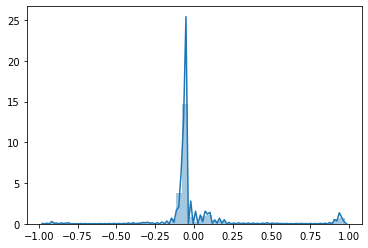

```python
sns.distplot(reg12.resid_response)
```

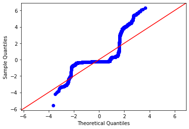

```python
p = qqplot(reg12.resid_pearson,line='45',fit='True')
```

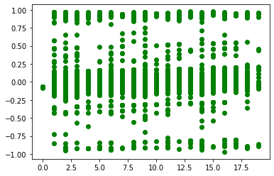

```python
plt.plot(emma_df2.chapter, reg12.resid_response, 'og')
```

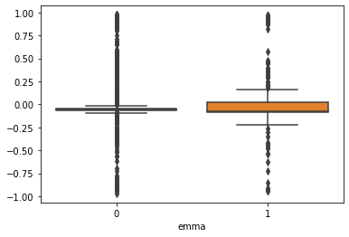

```python
sns.boxplot(x=emma_df2.emma, y=reg12.resid_response)
```

A little bit of heteroskedasticity

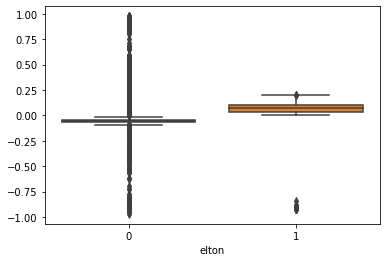

```python
sns.boxplot(x=emma_df2.elton, y=reg12.resid_response)
```

A lot of heteroskedasticity